# Wine Analysis

### Numerical Analysis

For the numerical analysis of these two datasets, R provides a simple summary() method. This shows statistical measurements such as Min., Median, Mean and Max of each column of the datasets.

#### Red Wines

```r
red_summary <- summary(red)

print(red_summary)
```

```
##  fixed.acidity   volatile.acidity  citric.acid    residual.sugar
##  Min.   : 4.60   Min.   :0.1200   Min.   :0.000   Min.   : 0.900
##  1st Qu.: 7.10   1st Qu.:0.3900   1st Qu.:0.090   1st Qu.: 1.900
##  Median : 7.90   Median :0.5200   Median :0.260   Median : 2.200
##  Mean   : 8.32   Mean   :0.5278   Mean   :0.271   Mean   : 2.539
##  3rd Qu.: 9.20   3rd Qu.:0.6400   3rd Qu.:0.420   3rd Qu.: 2.600
##  Max.   :15.90   Max.   :1.5800   Max.   :1.000   Max.   :15.500
##    chlorides       free.sulfur.dioxide total.sulfur.dioxide    density
##  Min.   :0.01200   Min.   : 1.00       Min.   :  6.00       Min.   :0.9901
##  1st Qu.:0.07000   1st Qu.: 7.00       1st Qu.: 22.00       1st Qu.:0.9956
##  Median :0.07900   Median :14.00       Median : 38.00       Median :0.9968
##  Mean   :0.08747   Mean   :15.87       Mean   : 46.47       Mean   :0.9967
##  3rd Qu.:0.09000   3rd Qu.:21.00       3rd Qu.: 62.00       3rd Qu.:0.9978
##  Max.   :0.61100   Max.   :72.00       Max.   :289.00       Max.   :1.0037
##        pH          sulphates         alcohol         quality
##  Min.   :2.740   Min.   :0.3300   Min.   : 8.40   Min.   :3.000
##  1st Qu.:3.210   1st Qu.:0.5500   1st Qu.: 9.50   1st Qu.:5.000
##  Median :3.310   Median :0.6200   Median :10.20   Median :6.000
##  Mean   :3.311   Mean   :0.6581   Mean   :10.42   Mean   :5.636
##  3rd Qu.:3.400   3rd Qu.:0.7300   3rd Qu.:11.10   3rd Qu.:6.000
##  Max.   :4.010   Max.   :2.0000   Max.   :14.90   Max.   :8.000
##   wine_type
##  Length:1599
##  Class :character
##  Mode  :character
##
##
##
```

#### White Wines

```r
white_summary <- summary(white)

print(white_summary)
```

```
##  fixed.acidity    volatile.acidity  citric.acid     residual.sugar
##  Min.   : 3.800   Min.   :0.0800   Min.   :0.0000   Min.   : 0.600
##  1st Qu.: 6.300   1st Qu.:0.2100   1st Qu.:0.2700   1st Qu.: 1.700
##  Median : 6.800   Median :0.2600   Median :0.3200   Median : 5.200
##  Mean   : 6.855   Mean   :0.2782   Mean   :0.3342   Mean   : 6.391
##  3rd Qu.: 7.300   3rd Qu.:0.3200   3rd Qu.:0.3900   3rd Qu.: 9.900
##  Max.   :14.200   Max.   :1.1000   Max.   :1.6600   Max.   :65.800
##    chlorides       free.sulfur.dioxide total.sulfur.dioxide    density
##  Min.   :0.00900   Min.   :  2.00      Min.   :  9.0        Min.   :0.9871
##  1st Qu.:0.03600   1st Qu.: 23.00      1st Qu.:108.0        1st Qu.:0.9917
##  Median :0.04300   Median : 34.00      Median :134.0        Median :0.9937
##  Mean   :0.04577   Mean   : 35.31      Mean   :138.4        Mean   :0.9940
##  3rd Qu.:0.05000   3rd Qu.: 46.00      3rd Qu.:167.0        3rd Qu.:0.9961
##  Max.   :0.34600   Max.   :289.00      Max.   :440.0        Max.   :1.0390
##        pH          sulphates         alcohol         quality
##  Min.   :2.720   Min.   :0.2200   Min.   : 8.00   Min.   :3.000
##  1st Qu.:3.090   1st Qu.:0.4100   1st Qu.: 9.50   1st Qu.:5.000
##  Median :3.180   Median :0.4700   Median :10.40   Median :6.000
##  Mean   :3.188   Mean   :0.4898   Mean   :10.51   Mean   :5.878
##  3rd Qu.:3.280   3rd Qu.:0.5500   3rd Qu.:11.40   3rd Qu.:6.000
##  Max.   :3.820   Max.   :1.0800   Max.   :14.20   Max.   :9.000
##   wine_type
##  Length:4898
##  Class :character
##  Mode  :character
##
##
##
```

The most important numerical takeaways here seem to be the ~ 6 average quality of the wines (with the white quality mean score being slightly above that of red!) as well as the subtle difference in values between the red and white datasets. These differences can be further explored through Graphical Analysis.

### Graphical Analysis

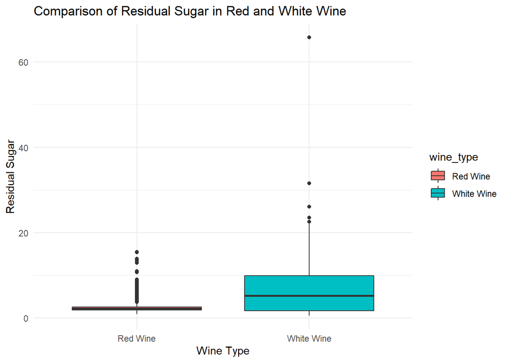

```r
# Create a boxplot to compare residual sugar between red and white wine
ggplot(combined_data, aes(x = wine_type, y = residual.sugar, fill = wine_type)) +
  geom_boxplot() +
  labs(title = "Comparison of Residual Sugar in Red and White Wine",
       x = "Wine Type",
       y = "Residual Sugar") +
  theme_minimal()
```

We can recreate this graph to compare other aspects of Red and White Wines :

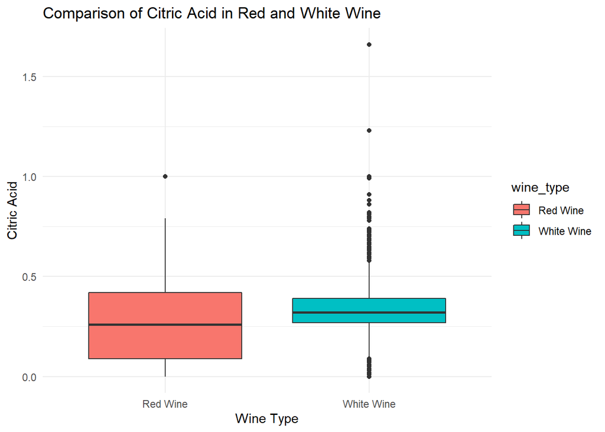

```r
ggplot(combined_data, aes(x = wine_type, y = citric.acid, fill = wine_type)) +
  geom_boxplot() +
  labs(title = "Comparison of Citric Acid in Red and White Wine",
       x = "Wine Type",
       y = "Citric Acid") +
  theme_minimal()
```

We can also compare the Alcohol content of Red and White Wines

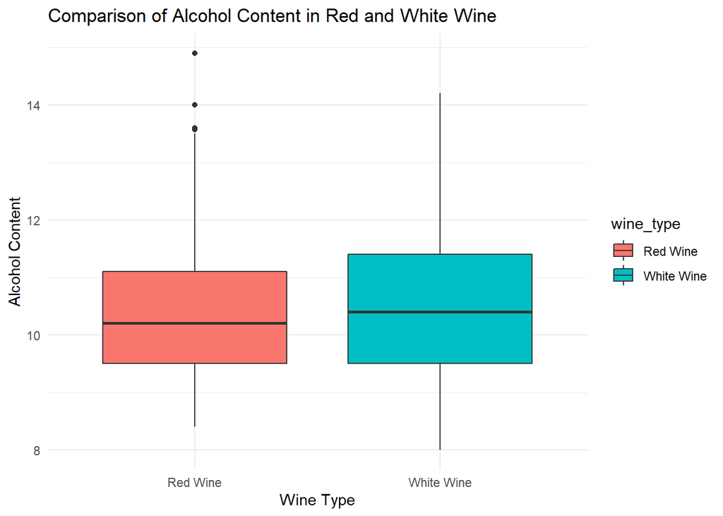

```r
ggplot(combined_data, aes(x = wine_type, y = alcohol, fill = wine_type)) +
  geom_boxplot() +
  labs(title = "Comparison of Alcohol Content in Red and White Wine",
       x = "Wine Type",
       y = "Alcohol Content") +
  theme_minimal()
```

And lastly, for quality

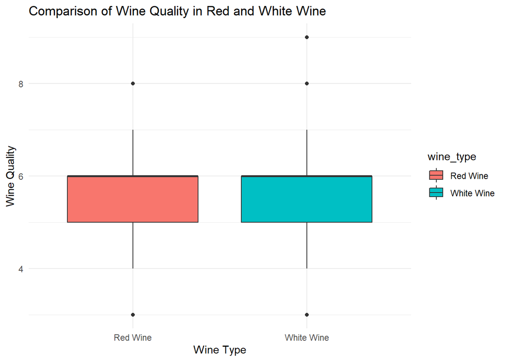

```r
ggplot(combined_data, aes(x = wine_type, y = quality, fill = wine_type)) +
  geom_boxplot() +
  labs(title = "Comparison of Wine Quality in Red and White Wine",
       x = "Wine Type",
       y = "Wine Quality") +
  theme_minimal()
```